# 3-1-44

## ニューロサイエンス後半レポート課題

学籍番号: 2140104005  
氏 名: 石丸 翔也

**課題**: 教科書の式(3.1.44)で学習規則が与えられるニューラルネットワークをCで実装し, 3—>2次元の変換を行う. 出力の2次元分布が入力の3次元データ分布の第一, 第二主成分で決定される平面と一致することを確認する. (C以外で実装する場合は行列計算のライブラリを使わないこと)

\begin{equation} W_{n + 1} = W_{n} + \eta_{n}(\overrightarrow{x}\overrightarrow{x}^{\mathsf T}W_{n} - W_{n}\Theta_{n}) + O(\eta_{n}^{2}) \end{equation}

```python
import random
import numpy as np
import matplotlib.pyplot as plt
from copy import deepcopy
%matplotlib inline
```

### 1. ニューラルネットワークによる次元変換の実装

実験に使用したパラメータを記す.

- $\Theta_{n}$ = $\overrightarrow{y}\overrightarrow{y}^{\mathsf T}$
- $\eta$ = 0.01
- $W_{n}$の初期値は0から1までの一様乱数を格納した縦3横2行列
- 入力 $\overrightarrow{x}$は平均0, 標準偏差1の正規分布をx軸9倍, y軸4倍, z軸にしたもの
- 10000個のデータセットで学習を行う
- 1つのデータに対して行う学習の回数は1000回

```python
ETA = 0.01
XPOWER = 9
YPOWER = 4
ZPOWER = 1
RAND_AVE = 0
RAND_STD = 1

DATA_COUNT = 10000
TRAIN_COUNT = 1000
```

与式の学習に必要な行列計算のプログラムを実装した.

```python
def product(A, B):
    """
    >>a = [[1,2, 3], [4, 5, 6]]
    >>b = [[1, 1], [1, 1], [1, 1]]
    >>print product(a,b) == [[6,6,],[15,15]]
    """
    AH = len(A)
    AW = len(A[0])
    BH = len(B)
    BW = len(B[0])
    if AW != BH:
        print "Size Error"
        print AW, BH
    res = [[0 for x in range(BW)] for y in range(AH)]
    for i in range(AH):
        for j in range(BW):
            for k in range(AW):
                res[i][j] += A[i][k] * B[k][j]
    return res

def transpose(A):
    """
    >>>a = [[1,2], [3,4]]
    >>>transpose(a) == [[1,3],[2,4]]
    True
    """
    AH = len(A)
    AW = len(A[0])
    res = [[0 for x in range(AH)] for y in range(AW)]
    for i in range(AH):
        for j in range(AW):
            res[j][i] = A[i][j]
    return res

def plus(A, B):
    """
    >>>a = [[1,2], [3,4]]
    >>>b = [[1, 0], [0, 1]]
    >>>plus(a,b) == [[2,2],[3,5]]
    True
    """
    AH = len(A)
    AW = len(A[0])
    res = [[0 for x in range(AW)] for y in range(AH)]
    for i in range(AH):
        for j in range(AW):
            res[i][j] = A[i][j] + B[i][j]
    return res

def minus(A, B):
    """
    >>>a = [[1,2], [3,4]]
    >>>b = [[1, 0], [0, 1]]
    >>>minus(a,b) == [[0,2],[3,3]]
    True
    """
    AH = len(A)
    AW = len(A[0])
    res = [[0 for x in range(AW)] for y in range(AH)]
    for i in range(AH):
        for j in range(AW):
            res[i][j] = A[i][j] - B[i][j]
    return res

def times(num, A):
    """
    >>>a = [[1,2], [3,4]]
    >>>times(2,a) == [[2,4],[6,8]]
    True
    """
    AH = len(A)
    AW = len(A[0])
    for i in range(AH):
        for j in range(AW):
            A[i][j] = A[i][j] * num
    return A

def calcX():
    return [
        [XPOWER * random.normalvariate(RAND_AVE, RAND_STD)],
        [YPOWER * random.normalvariate(RAND_AVE, RAND_STD)],
        [ZPOWER * random.normalvariate(RAND_AVE, RAND_STD)]]

def calcW1():
    return [[random.random() for x in range(2)] for y in range(3)]

def NN(Wn):
    y = product(transpose(Wn), X)
    theata = product(y, transpose(y))
    return plus(Wn, times(ETA, minus(product(X, (product(transpose(X), Wn))), product(Wn, theata)))), y
```

### 2. 予備実験

実装したニューラルネットワークの重み$W_{n}$が学習により収束することを確認した.  
下図は$W_{n}$の(0,0)成分を例として挙げ, 学習の様子をプロットしたものである.

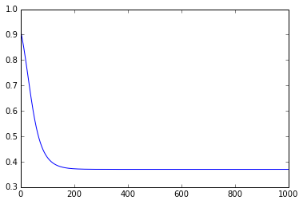

```python
W = calcW1()
X = calcX()
W00 = []
for i in range(TRAIN_COUNT):
    W, y = NN(W)
    W00.append(W[0][0])
plt.plot(W00)
```

### 3. 実験

10000個のデータセットで学習を行った.  
次元変換されたデータをysという変数で取り出している.

```python
data = [calcX() for x in range(DATA_COUNT)]
Ws = []
ys = []
for X in data:
    W = calcW1()
    for i in range(1000):
        W, y = NN(W)
    Ws.append(W)
    ys.append(y)
```

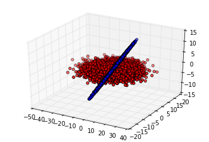

```python
from mpl_toolkits.mplot3d import Axes3D
ax = plt.figure().add_subplot(111, projection='3d')

data_ = np.array(data).reshape((DATA_COUNT, 3)).T
ax.scatter(data_[0], data_[1], data_[2],c='r')

y = np.array(ys).reshape((DATA_COUNT,2,1))
d = np.array([product(W,y[x]) for x in range(len(y))])
d = d.reshape((DATA_COUNT, 3)).T
ax.scatter(d[0], d[1], d[2], c='b')
```

### 4. 考察

予備実験の出力結果からは, およそ200回の学習で$W_{n}$が収束することが確認できる.